# Reproducible Reports & Version Control

## Welcome to our first class!

- We didn’t meet on Monday — you worked through setup and R basics on your own.
- **Quick check:** everyone should have R, RStudio, and Git installed. If not, see me right after class.
- **Topic:** Reproducible Reports & Version Control
- **Today’s Goals:**
  - Learn how to create dynamic, reproducible reports using R Markdown.
  - Understand the basics of version control with Git.
  - See how to collaborate using GitHub.
- **Why is this important?** Reproducibility is the cornerstone of good data science. It ensures your work is transparent, verifiable, and easy to share.

## How this course works

- See the Syllabus for the complete breakdown
- Typical class:
  - Short lecture on the concept we will focus on
  - In-class activity to apply the concepts we just covered
- Evaluation:
  - Attendance [5%]
  - Activities [5%]
  - Problem sets (0/1/2 scale) [5%]
  - Team projects [15%]
  - Midterm 1 [25%]
  - Midterm 2 [25%]
  - Final project [20%]

## Using AI in This Course

- Great for assisting with skills you already have
  - Over-relying on it is really just outsourcing your learning
  - It can be *so* helpful that it actually gets in the way of you learning
- It makes mistakes and can lead debugging astray
  - Knowing the underlying code yourself is what lets you catch this and respond in real time
- For the ML models we’ll cover, **intuition** matters more than writing code from scratch
  - Understanding *why* something works beats memorizing syntax
- **Bottom line:** use it to build understanding, not replace it
  - 50% of your grade (both midterms) is real-time, no-AI — that’s where we check what you actually know

## Activities

- Each in-class activity gets pushed to your assignment repo before you leave
  - Graded on **completion**, not correctness
  - This is the 5% Activities grade
- Partway through the activity, I’ll cold-call one student (at random) to walk through what they’ve done and any issues they’ve hit
  - Also graded 0/1, and also counts toward the 5% Activities grade
  - If you’re stuck when called on, that’s useful information for me too, not just a grade

## How to succeed

- Stay up to date with the course outline (I will update regularly)
- Come to class prepared and on time
- Ask questions if you start getting lost
  - In class
  - Tutor OH
  - My OH

## About Me

- Los Angeles area native
- B.S. Information Systems (kind of like data science), Carnegie Mellon University, 2005
- Sales and Trading at Deutsche Bank in NYC for 2 years
- Ph.D. University of Michigan, 2017
  - Became interested in economics/data after working on Wall St.
  - Didn’t have much of a quantitative background going in
  - I think data science is a great tool in general but especially for economics

## Outside of Class

- Rock climbing
- Stock trading/investing
- Video games (RPGs / sim games / local co-op games with my wife)

## Climbing in Tahquitz (Idyllwild)

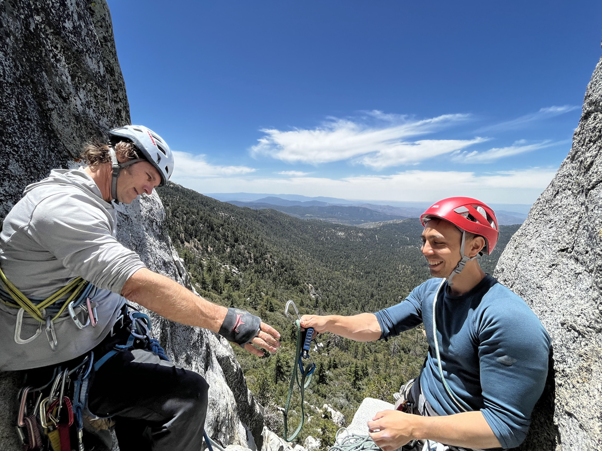

## What is R Markdown?

- R Markdown is a powerful tool for creating dynamic documents from R.
- It combines text, R code, and the output of that code into a single, elegant report.
- **Key Idea:** If someone else has your R Markdown file and your data, they can recreate your exact analysis and report.

## The Anatomy of an R Markdown File

An R Markdown file (`.Rmd`) has three main components:

1. **YAML Header:** Metadata at the top, enclosed by `---`.

   ```yaml
   ---
   title: "My First R Markdown Report"
   author: "Your Name"
   date: "August 31, 2026"
   output: html_document
   ---
   ```

2. **Text:** The narrative of your report, written in Markdown.
3. **Code Chunks:** Sections of R code that are executed and whose output is displayed.

## Basic Markdown Syntax

You can use simple Markdown to format your text.

- `# Header 1`
- `## Header 2`
- `### Header 3`
- `Item 1`
- `Item 2`
- `**Bold text** and *italic text*.`
- `[A link to Google](https://www.google.com)`

## Your First Code Chunk

A code chunk is delimited by three backticks and `{r}`. Everything inside runs as R code when you knit.

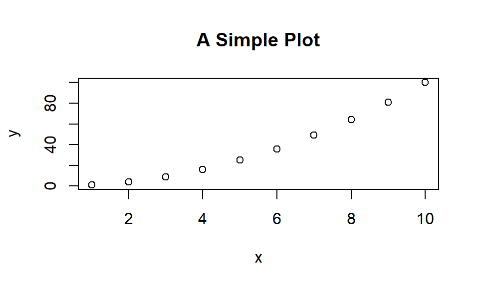

```r
x <- 1:10
y <- x^2
plot(x, y, main = "A Simple Plot")
```

## Code Chunk Options

Code chunks have powerful options to control their behavior.

- `echo=FALSE`: Hide the code, but show the output. Useful for final report.
- `eval=FALSE`: Show the code, but don’t run it. Useful for examples.
- `include=FALSE`: Hide both the code and the output. When you want to load something.
- `message=FALSE`: Suppress any messages generated by the code.

## Code Chunk Options: `echo=FALSE`

Same plot as before, but with `echo=FALSE` — code is hidden, only the output shows:

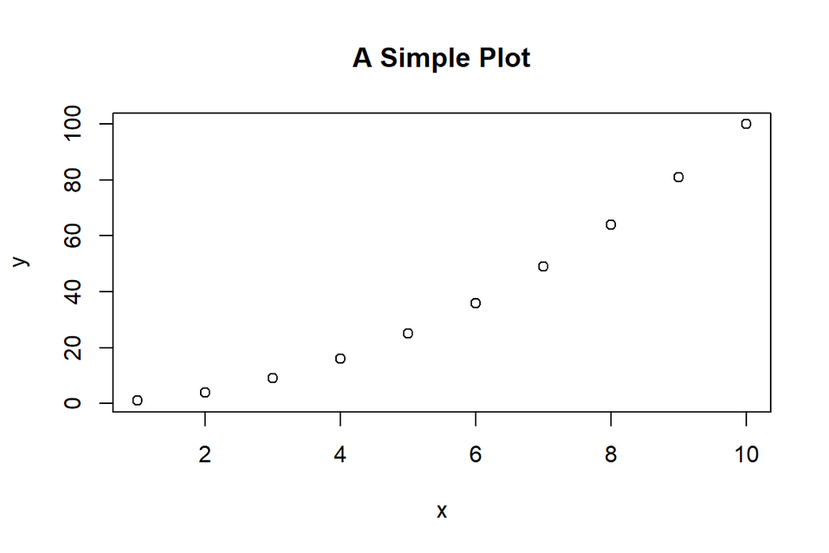

## Displaying a Table

R Markdown can easily display data tables. Here’s the built-in `mtcars` dataset:

```r
head(mtcars)
```

```
##                    mpg cyl disp  hp drat    wt  qsec vs am gear carb
## Mazda RX4         21.0   6  160 110 3.90 2.620 16.46  0  1    4    4
## Mazda RX4 Wag     21.0   6  160 110 3.90 2.875 17.02  0  1    4    4
## Datsun 710        22.8   4  108  93 3.85 2.320 18.61  1  1    4    1
## Hornet 4 Drive    21.4   6  258 110 3.08 3.215 19.44  1  0    3    1
## Hornet Sportabout 18.7   8  360 175 3.15 3.440 17.02  0  0    3    2
## Valiant           18.1   6  225 105 2.76 3.460 20.22  1  0    3    1
```

## Combining Text and Code (Inline Code)

Wrap an R expression in an inline code span — a single backtick, a lowercase `r`, then your expression, then a closing backtick — right inside a normal sentence. Type this in your prose:

The average MPG is `r mean(mtcars$mpg)`.

When you knit, it gets evaluated and substituted in — here’s that exact same line, live:

We can calculate the average miles per gallon of the `mtcars` dataset. The average MPG is 20.090625.

- Much better than hardcoding values

## Your Turn

- This is just a preview – you’ll practice the commands in today’s activity

## Knitting Your Report

The “Knit” button turns your `.Rmd` file into a final document.

- **github_document** (creates a .md Markdown doc): default for assignments – easy to view in github
- **html_document** (can’t view in GitHub)
- **pdf_document** (need MikTex or MacTex installed)
- **ioslides_presentation**: Nice when you want to convert your document into slides with dynamic references
- for help: in Rstudio select `Help > Cheatsheets > R Markdown Cheat Sheet`

**Summary:** R Markdown makes your analysis transparent and easy to update.

## Why Version Control?

- Imagine working on a project and saving files like
  - `my_analysis_v1.R`
  - `my_analysis_final.R`
  - `my_analysis_final_final.R`.

This is confusing!

- **Git** solves this. It’s a system that records changes to a file or set of files over time, so you can recall specific versions later.
- RStudio has fantastic built-in Git integration, so you can focus on your data analysis, not file management.

## Step 1: Join the Class Organization (One-Time)

**Starting today, activities are submitted through Classroom 50 — this is where your copy of the repo comes from.**

1. Accept the email invite to the **econ122-f26** GitHub organization — you can’t accept any assignment until you’ve joined.
2. Go to **classroom50.org** and sign in with GitHub.
3. Confirm you see **econ122-f26** listed as one of your organizations.

You only need to do this once, at the start of the semester.

## Step 2: Accept Today’s Assignment

1. Click the assignment link: **classroom50.org/econ122-f26/econ122-f26/assignments/day2-activity/accept**
2. Confirm to accept — this creates a private repository just for you, with the starter code (this activity file) already inside it.
3. Copy the repo’s HTTPS URL (green **“Code”** button).

## Step 3: Clone Your Assignment Repo into RStudio

**This downloads a local copy of your repo.**

1. In RStudio, go to `File > New Project...`
2. Select **“Version Control”** then **“Git”**.
3. Paste the URL you just copied into the **“Repository URL”** field.
4. Choose a project directory name and click **“Create Project”**.

RStudio will download a copy of the project and its history, and the Git tab will appear automatically.

## The RStudio Git View

RStudio makes the three stages of Git very visual:

1. **Working Directory:** Your project files, as seen in the “Files” pane.
2. **Staging Area:** The **“Staged”** column in the **“Git”** tab. A checked box means the change is ready to be committed.
3. **Git Repository:** The history of your commits, which you can view with the **“History”** button in the Git tab.

## Your First Commit and Push

Today, that means committing and pushing your work on `day2_activity.Rmd` — this is how you actually submit it.

1. Open `day2_activity.Rmd` in your cloned project and work through the activity.
2. Once you’ve saved changes, you’ll see the file listed in the **“Git”** tab with a yellow status icon.
3. **Stage the file:** Click the **“Staged”** checkbox next to it.
4. **Commit the change:** Click **“Commit”**. Write a clear message (e.g., “Completed Part 1 of the activity”) and click **“Commit”**.
5. **Push the change:** Close the commit window and click the green **“Push”** (up arrow) button — this sends your work to GitHub, where I can see and grade it.

## Pulling Changes from Others

When working in a team, others will also be pushing changes. You need to pull their changes to your local machine to stay up to date.

- **Pulling:** Click the blue **“Pull”** (down arrow) button in the Git tab.
- **Best Practice:** Always “Pull” before you start working and before you “Push” your own changes. This helps avoid conflicts.

## Summary

- **R Markdown:** A single document that combines text and code for creating reproducible reports.
- **Git:** A local tool for tracking changes in your files.
- **GitHub:** A remote service for storing your Git repositories, enabling collaboration and backups.
- **RStudio:** Integrates seamlessly with Git to provide a simple, visual workflow.

## For rest of class

- Work on the `day2_activity`
- Ask me questions if you run into issues